# Analysis CATegories Pilot

Anonymized

30 December, 2021

## Load packages

```r
library(tidyverse)
library(janitor)
library(cowplot)
library(here)
library(readxl)
theme_set(theme_cowplot())

knitr::opts_chunk$set(cache = FALSE, warn = FALSE,warning=FALSE, message = FALSE)
```

## Load data

```r
data_file_path <- here::here("..","data","CATegories_exp1_pilot_processed_data.csv")

d <- read_csv(data_file_path)

## add general category properties from typicality dataset
## typicality
animal_rating_names <- read.csv(here::here("..","data","animal_ratings_stimuli_full.csv"))
animal_stims <- unique(c(unique(d$left_image),unique(d$right_image)))
typicality <- read.csv(here::here("..","data","typicality_animals_summarized.csv")) %>%
  mutate(item_name=str_remove(animal_name,pattern=" ")) %>%
  left_join(animal_rating_names) %>%
  filter(imageName %in% animal_stims)
d <- d %>%
  left_join(typicality %>% select(imageName,category,typicality_subjective),by=c("target_image" = "imageName")) %>%
  rename(typicality_condition=typicality_subjective)
```

## Summarize participant information

```r
#summarize subj info
subj_info <- d %>%
  distinct(sub_num, age,months,age_mo, sex, trial_order) %>%
  summarize(
    N = n(),
    mean_age = mean(age_mo),
    sd_age = sd(age_mo),
    N_female = sum(sex=="female")
  )
subj_info %>%
  knitr::kable()
```

| N | mean_age | sd_age | N_female |
| --- | --- | --- | --- |
| 41 | 14.73902 | 2.174382 | 20 |

## Useable trial summary

In order for a trial to be included, participants must contribute at least 50% looking during the windows of interest when computing baseline-corrected proportion target looking: the critical window (300 ms - 2800 ms relative to target word onset) and the baseline window (-2000 ms - 0 ms relative to target word onset).

```r
critical_window <- c(300,2800)
baseline_window <- c(-2000,0)

summarize_subj_useable_trials_critical_window <- d %>%
  filter(corrected_time_centered>=critical_window[1]&corrected_time_centered<=critical_window[2]) %>%
  group_by(sub_num, months,age_mo, sex, trial_order,trial_number,target_image,target_typicality_z) %>%
  summarize(
    length_critical_window=n(),
    useable_frames_critical_window=sum(!is.na(accuracy_transformed)),
    percent_useable_critical_window=useable_frames_critical_window/length_critical_window,
    useable_critical_window=ifelse(percent_useable_critical_window>=0.5,1,0), #useable if at least 50% looking
    mean_target_looking_critical=mean(accuracy_transformed,na.rm=TRUE)
  )

summarize_subj_useable_trials_baseline_window <- d %>%
  filter(corrected_time_centered>=baseline_window[1] & corrected_time_centered<=baseline_window[2]) %>%
  group_by(sub_num, months,age_mo, sex, trial_order,trial_number,target_image,target_typicality_z) %>%
  summarize(
    length_baseline_window=n(),
    useable_frames_baseline_window=sum(!is.na(accuracy_transformed)),
    percent_useable_baseline_window=useable_frames_baseline_window/length_baseline_window,
    useable_baseline_window=ifelse(percent_useable_baseline_window>=0.5,1,0), #useable if at least 50% looking
    mean_target_looking_baseline=mean(accuracy_transformed,na.rm=TRUE)
  )

#overall useable trials
summarize_subj_useable_trials <- summarize_subj_useable_trials_critical_window %>%
  left_join(summarize_subj_useable_trials_baseline_window) %>%
  mutate(
    useable_window = ifelse(useable_baseline_window==1&useable_critical_window==1,1,0),
    corrected_target_looking = mean_target_looking_critical - mean_target_looking_baseline
  )


summarize_useable_trials <- summarize_subj_useable_trials %>%
  group_by(sub_num, months, sex, trial_order) %>%
  summarize(
    num_useable_trials=sum(useable_window),
    num_useable_trials_critical_window = sum(useable_critical_window),
    exclude_participant=ifelse(num_useable_trials<8,1,0), # must contribute at least half of the total trials (n=16 in pilot),
    exclude_participant_critical=ifelse(num_useable_trials_critical_window<8,1,0)
  )

#average trials contributed
mean(summarize_useable_trials$num_useable_trials)
```

```
## [1] 12.68293
```

```r
#participants to exclude based on data contribution
sum(summarize_useable_trials$exclude_participant)
```

```
## [1] 4
```

```r
#join with main data frame
summarize_subj_useable_trials <- summarize_subj_useable_trials %>%
  left_join(summarize_useable_trials)
d <- d %>%
  left_join(summarize_subj_useable_trials)
```

## Summarize subject-level accuracy

Here, we summarize each participants’ average accuracy during the critical window and average baseline-corrected proportion target looking.

```r
# critical window only
avg_critical_window_accuracy <- d %>%
  filter(exclude_participant_critical==0) %>%
  filter(useable_critical_window==1) %>%
  filter(corrected_time_centered>=300&corrected_time_centered<=2800) %>%
  group_by(sub_num, months,age_mo,age_group, sex, trial_order,trial_number,target_image,target_typicality_z) %>%
  summarize(mean_accuracy=mean(accuracy_transformed,na.rm=TRUE)) %>%
  ungroup() %>%
  group_by(sub_num, age_mo,age_group, sex, trial_order) %>%
  summarize(N=n(),
            accuracy=mean(mean_accuracy,na.rm=TRUE),
            ci=qt(0.975, N-1)*sd(mean_accuracy,na.rm=T)/sqrt(N),
            lower_ci=accuracy-ci,
            upper_ci=accuracy+ci)

#baseline-corrected target looking
avg_corrected_target_looking <- d %>%
  filter(exclude_participant==0) %>%
  filter(useable_window==1) %>%
  distinct(sub_num, months,age_mo,age_group, sex, trial_order,trial_number,target_image,target_typicality_z,mean_target_looking_critical,mean_target_looking_baseline,corrected_target_looking) %>%
  group_by(sub_num, age_mo,age_group, sex, trial_order) %>%
  summarize(N=n(),
            average_corrected_target_looking=mean(corrected_target_looking,na.rm=TRUE),
            ci=qt(0.975, N-1)*sd(corrected_target_looking,na.rm=T)/sqrt(N),
            lower_ci=average_corrected_target_looking-ci,
            upper_ci=average_corrected_target_looking+ci)
```

## Simple exploratory t-tests investigating baseline-corrected accuracy compared to chance

To provide a quick, descriptive summary of participant-level proportion target looking (baseline-corrected), we conduct one-sample and independent samples t-tests. Infants below 14 months (crude cutoff) are at chance, infants above 14 months are reliably identifying targets.

```r
#significant looking overall
t.test(avg_corrected_target_looking$average_corrected_target_looking,mu=0)
```

```
##
##  One Sample t-test
##
## data:  avg_corrected_target_looking$average_corrected_target_looking
## t = 3.7323, df = 36, p-value = 0.0006532
## alternative hypothesis: true mean is not equal to 0
## 95 percent confidence interval:
##  0.03148161 0.10641144
## sample estimates:
##  mean of x
## 0.06894653
```

```r
#word recognition is robust for infants above 14 months of age
t.test(filter(avg_corrected_target_looking,age_group=="older than 14 months")$average_corrected_target_looking,mu=0)
```

```
##
##  One Sample t-test
##
## data:  filter(avg_corrected_target_looking, age_group == "older than 14 months")$average_corrected_target_looking
## t = 3.9216, df = 20, p-value = 0.000845
## alternative hypothesis: true mean is not equal to 0
## 95 percent confidence interval:
##  0.04863519 0.15916940
## sample estimates:
## mean of x
## 0.1039023
```

```r
#infants below 14 months at chance
t.test(filter(avg_corrected_target_looking,age_group=="younger than 14 months")$average_corrected_target_looking,mu=0)
```

```
##
##  One Sample t-test
##
## data:  filter(avg_corrected_target_looking, age_group == "younger than 14 months")$average_corrected_target_looking
## t = 1.1279, df = 15, p-value = 0.2771
## alternative hypothesis: true mean is not equal to 0
## 95 percent confidence interval:
##  -0.02052321  0.06665738
## sample estimates:
##  mean of x
## 0.02306708
```

```r
#older infants do better than infants below 14 months of age
t.test(filter(avg_corrected_target_looking,age_group=="younger than 14 months")$average_corrected_target_looking,filter(avg_corrected_target_looking,age_group=="older than 14 months")$average_corrected_target_looking,var.equal=T)
```

```
##
##  Two Sample t-test
##
## data:  filter(avg_corrected_target_looking, age_group == "younger than 14 months")$average_corrected_target_looking and filter(avg_corrected_target_looking, age_group == "older than 14 months")$average_corrected_target_looking
## t = -2.2924, df = 35, p-value = 0.02801
## alternative hypothesis: true difference in means is not equal to 0
## 95 percent confidence interval:
##  -0.152421294 -0.009249126
## sample estimates:
##  mean of x  mean of y
## 0.02306708 0.10390229
```

## Accuracy across age

### Critical Window Only

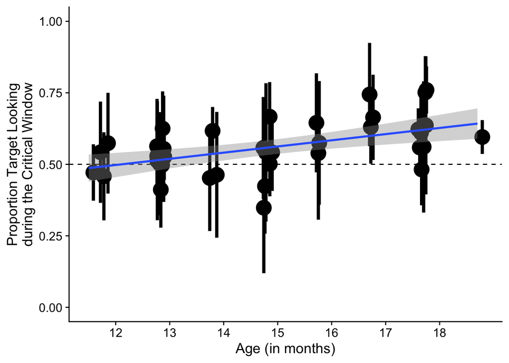

```r
ggplot(avg_critical_window_accuracy,aes(age_mo,accuracy))+
  geom_pointrange(aes(ymin=lower_ci,ymax=upper_ci),
                  position=position_jitter(width=0.1),
                  width=0,
                  size=1.5) +
  geom_hline(yintercept=0.5,linetype="dashed")+
  geom_smooth(method="lm")+
  xlab("Age (in months)")+
  ylab("Proportion Target Looking\nduring the Critical Window")+
  ylim(0,1)+
  scale_x_continuous(breaks=seq(12,18,1))
```

```r
ggsave(here::here("..","figures","age_relationship_critical_window_accuracy.png"),width=7,height=6)
```

### Baseline-corrected proportion target looking

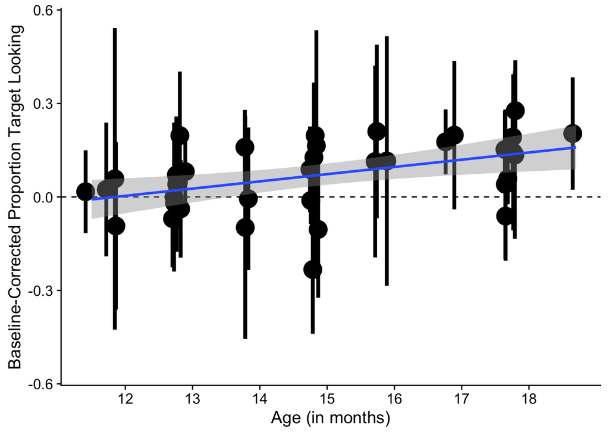

```r
ggplot(avg_corrected_target_looking,aes(age_mo,average_corrected_target_looking))+
  geom_pointrange(aes(ymin=lower_ci,ymax=upper_ci),
                  position=position_jitter(width=0.1),
                  width=0,
                  size=1.5) +
  geom_hline(yintercept=0,linetype="dashed")+
  geom_smooth(method="lm")+
  xlab("Age (in months)")+
  ylab("Baseline-Corrected Proportion Target Looking")+
  ylim(-0.55,0.55)+
  scale_x_continuous(breaks=seq(12,18,1))
```

```r
ggsave(here::here("..","figures","age_relationship_baseline_corrected_accuracy.png"),width=7,height=6)
```

## Timecourse plot

In order to plot participants’ average proportion looking to the target across the trial, we smooth/ resample time. This is necessary when plotting the timecourses given the variable sampling rate in the data (otherwise the mean observations “jump around” due to varying contributing data composition at different time points).

```r
target_ms_per_frame=1000/30
#adapted from: https://github.com/langcog/peekds/blob/master/R/generate_aoi.R
resample_trial <- function(df_trial) {
  t_origin <- df_trial$corrected_time_centered
  data_origin <- df_trial$accuracy_transformed

  # create the new timestamps for resampling
  t_start <- min(t_origin) - (min(t_origin) %% target_ms_per_frame)
  t_resampled <- seq(from = t_start, to = max(t_origin),
                     by = target_ms_per_frame)

  # exchange strings values with integers for resampling
  # this step critical for interpolating missing vals quickly and correctly
  aoi_num <- data_origin %>%
    recode(.missing = 2) #recode NA as 2

  # start resampling with approx
  aoi_resampled <- stats::approx(x = t_origin, y = aoi_num, xout = t_resampled,
                                 method = "constant", rule = 2,
                                 ties = "ordered")$y
  aoi_resampled_recoded <- aoi_resampled %>%
    dplyr::recode("0"="0","1"="1","2" = "missing") %>%
    as.numeric()

  # adding back the columns to match schema
  dplyr::tibble(corrected_time_centered = t_resampled,
                accuracy_transformed = aoi_resampled_recoded,
                trial_number = df_trial$trial_number[1],
                sub_num = df_trial$sub_num[1])
}

d_resampled <- d %>%
  dplyr::mutate(sub_num_trial_number = paste(.data$sub_num,
                                           .data$trial_number, sep = "_")) %>%
      split(.$sub_num_trial_number) %>%
      purrr::map_df(resample_trial) %>%
      dplyr::arrange(.data$sub_num, .data$trial_number)

d_info <- d %>%
  select(-corrected_time_centered,-accuracy_transformed) %>%
  distinct(sub_num, exclude_participant, useable_window, months,age_mo, age_group,sex, trial_order, condition, trial_order,trial_number,target_image,target_typicality_z)

d_resampled <- d_resampled %>%
  left_join(d_info) %>%
  mutate(corrected_time_centered =round(corrected_time_centered,0))
```

Next, we summarize the data in two steps: (1) summarize the data by subject for each time point, followed by (2) averaging looking for each time point across subjects.

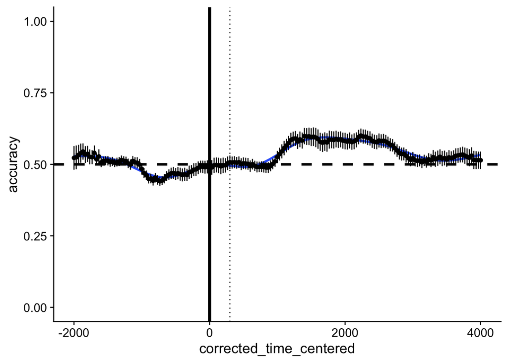

```r
#summarizing within subject for each time point
summarize_subj <- d_resampled %>%
  filter(exclude_participant==0) %>%
  filter(useable_window==1) %>%
  group_by(sub_num, months,age_mo, sex, trial_order, corrected_time_centered) %>%
  summarize(N=n(),
            non_na_n = sum(!is.na(accuracy_transformed)),
            mean_accuracy=mean(accuracy_transformed,na.rm=TRUE),
            ci=qt(0.975, non_na_n-1)*sd(accuracy_transformed,na.rm=T)/sqrt(non_na_n),
            lower_ci=mean_accuracy-ci,
            upper_ci=mean_accuracy+ci) %>%
  ungroup()

#summarizing across subjects for each time point
summarize_across_subj <- summarize_subj %>%
  group_by(corrected_time_centered) %>%
  dplyr::summarize(n=n(),
            accuracy=mean(mean_accuracy,na.rm=TRUE),
            sd_accuracy=sd(mean_accuracy,na.rm=TRUE),
            se_accuracy=sd_accuracy/sqrt(n))

ggplot(summarize_across_subj,aes(corrected_time_centered,accuracy))+
  xlim(-2000,4000)+
  geom_smooth(method="gam")+
  geom_errorbar(aes(ymin=accuracy-se_accuracy,ymax=accuracy+se_accuracy),width=0)+
  geom_point()+
  geom_vline(xintercept=0,size=1.5)+
  geom_hline(yintercept=0.5,size=1.2,linetype="dashed")+
  geom_vline(xintercept=300,linetype="dotted")
```

```r
ggsave(here::here("..","figures","overall_accuracy.png"))
```

### Timecourse by age

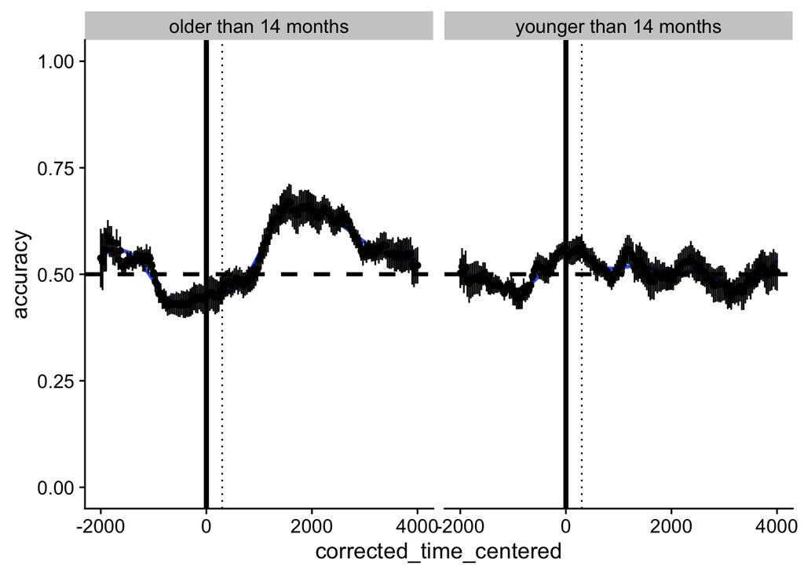

```r
summarize_across_subj_by_age <- summarize_subj %>%
  mutate(age_group=ifelse(age_mo>14,"older than 14 months","younger than 14 months")) %>%
  group_by(age_group,corrected_time_centered) %>%
  dplyr::summarize(n=n(),
                   accuracy=mean(mean_accuracy,na.rm=TRUE),
                   sd_accuracy=sd(mean_accuracy,na.rm=TRUE),
                   se_accuracy=sd_accuracy/sqrt(n))
ggplot(summarize_across_subj_by_age,aes(corrected_time_centered,accuracy))+
  xlim(-2000,4000)+
  geom_smooth(method="gam")+
  geom_errorbar(aes(ymin=accuracy-se_accuracy,ymax=accuracy+se_accuracy),width=0)+
  geom_point()+
  geom_vline(xintercept=0,size=1.5)+
  geom_hline(yintercept=0.5,size=1.2,linetype="dashed")+
  geom_vline(xintercept=300,linetype="dotted")+
  facet_wrap(~age_group)
```

```r
ggsave(here::here("..","figures","overall_accuracy_by_age.png"),width=12, height=9)
```

### Timecourse by condition and age

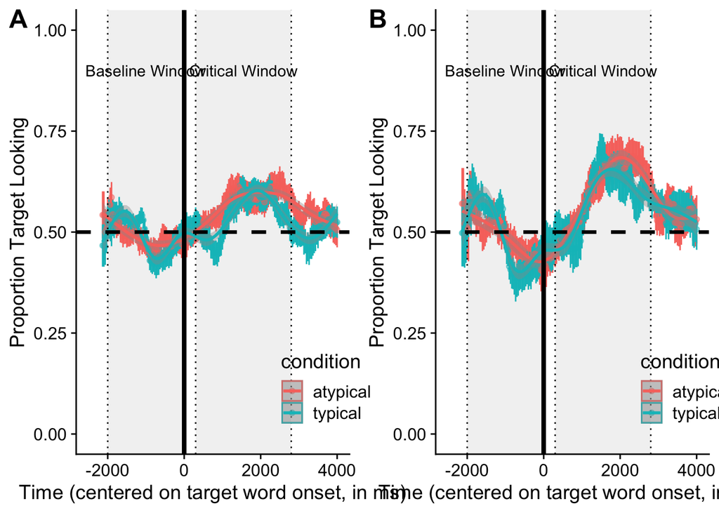

```r
summarize_subj_condition <- d_resampled %>%
  filter(exclude_participant==0) %>%
  filter(useable_window==1) %>%
  group_by(sub_num, months,age_mo,age_group, sex, condition, trial_order, corrected_time_centered) %>%
  summarize(mean_accuracy=mean(accuracy_transformed,na.rm=TRUE))

summarize_across_subj_cond_by_age <- summarize_subj_condition %>%
  group_by(age_group,condition,corrected_time_centered) %>%
  summarize(n=n(),
            accuracy=mean(mean_accuracy,na.rm=TRUE),
            sd_accuracy=sd(mean_accuracy,na.rm=TRUE),
            se_accuracy=sd_accuracy/sqrt(n))

num_subjects <- summarize_across_subj_cond_by_age%>%
  group_by(age_group)%>%
  summarize(max_subnum=max(n))

summarize_across_subj_cond<- summarize_subj_condition %>%
  group_by(condition,corrected_time_centered) %>%
  summarize(n=n(),
            accuracy=mean(mean_accuracy,na.rm=TRUE),
            sd_accuracy=sd(mean_accuracy,na.rm=TRUE),
            se_accuracy=sd_accuracy/sqrt(n))

pA <- ggplot(summarize_across_subj_cond,aes(corrected_time_centered,accuracy,color=condition))+
  xlim(-2500,4000)+
  geom_rect(data = data.frame(xmin = 300,
                              xmax = 2800,
                              ymin = -Inf,
                              ymax = Inf),
            aes(x=NULL, y=NULL,xmin = xmin, xmax = xmax, ymin = ymin, ymax = ymax,color=NULL),
            fill = "grey", alpha = 0.2)+
  geom_rect(data = data.frame(xmin = -2000,
                              xmax = 0,
                              ymin = -Inf,
                              ymax = Inf),
            aes(x=NULL, y=NULL,xmin = xmin, xmax = xmax, ymin = ymin, ymax = ymax,color=NULL),
            fill = "grey", alpha = 0.2)+
  geom_errorbar(aes(ymin=accuracy-se_accuracy,ymax=accuracy+se_accuracy),width=0)+
  geom_point(alpha=0.5)+
  geom_smooth(data=summarize_subj_condition,aes(y=mean_accuracy),method="gam")+
  geom_vline(xintercept=0,size=1.5)+
  geom_hline(yintercept=0.5,size=1.2,linetype="dashed")+
  geom_vline(xintercept=300,linetype="dotted")+
  geom_vline(xintercept=2800,linetype="dotted")+
  geom_vline(xintercept=-2000,linetype="dotted")+
  geom_vline(xintercept=0,linetype="dotted")+
  theme(legend.position = c(0.75,0.15))+
  annotate("text",label="Critical Window",x=1550,y=0.9)+
  annotate("text",label="Baseline Window",x=-1000,y=0.9)+
  ylim(0,1)+
  ylab("Proportion Target Looking")+
  xlab("Time (centered on target word onset, in ms)")
ggsave(here::here("..","figures","typicality_accuracy.png"),width=10,height=6)

pB <- ggplot(filter(summarize_across_subj_cond_by_age,age_group=="older than 14 months"),aes(corrected_time_centered,accuracy,color=condition))+
  xlim(-2500,4000)+
  geom_rect(data = data.frame(xmin = 300,
                              xmax = 2800,
                              ymin = -Inf,
                              ymax = Inf),
            aes(x=NULL, y=NULL,xmin = xmin, xmax = xmax, ymin = ymin, ymax = ymax,color=NULL),
            fill = "grey", alpha = 0.2)+
  geom_rect(data = data.frame(xmin = -2000,
                              xmax = 0,
                              ymin = -Inf,
                              ymax = Inf),
            aes(x=NULL, y=NULL,xmin = xmin, xmax = xmax, ymin = ymin, ymax = ymax,color=NULL),
            fill = "grey", alpha = 0.2)+
  geom_errorbar(aes(ymin=accuracy-se_accuracy,ymax=accuracy+se_accuracy),width=0)+
  geom_point(alpha=0.5)+
  geom_smooth(data=filter(summarize_subj_condition,age_group=="older than 14 months"),aes(y=mean_accuracy),method="gam")+
  geom_vline(xintercept=0,size=1.5)+
  geom_hline(yintercept=0.5,size=1.2,linetype="dashed")+
  geom_vline(xintercept=300,linetype="dotted")+
  geom_vline(xintercept=2800,linetype="dotted")+
  geom_vline(xintercept=-2000,linetype="dotted")+
  geom_vline(xintercept=0,linetype="dotted")+
  theme(legend.position = c(0.75,0.15))+
  annotate("text",label="Critical Window",x=1550,y=0.9)+
  annotate("text",label="Baseline Window",x=-1000,y=0.9)+
  ylim(0,1)+
  ylab("Proportion Target Looking")+
  xlab("Time (centered on target word onset, in ms)")
ggsave(here::here("..","figures","typicality_accuracy_only14mosorolder.png"),width=10,height=6)

plot_grid(pA,pB,ncol=2,label_size=18,labels=c("A","B"))
```

```r
ggsave(here::here("..","figures","typicality_accuracy_paper.png"),width=12,height=6)
```

## Target Looking By Item

Next, we investigate item-level (target word) variation in proportion target looking.

### Overall target looking during critical window and baseline window

First, we inspect overall target looking in the critical window and in the baseline window. Note the baseline effects, such that dog and cat are more likely to be fixated during baseline than bird and fish.

```r
#average target looking during the baseline and critical window by item for each subject
avg_subj_target_looking_by_item <- d %>%
  filter(exclude_participant==0) %>%
  filter(useable_window==1) %>%
  distinct(sub_num, months,age_mo,age_group, sex, trial_order,trial_number,category,target_image,target_typicality_z,mean_target_looking_critical,mean_target_looking_baseline,corrected_target_looking) %>%
  group_by(sub_num, age_mo,age_group, sex, trial_order,category) %>%
  summarize(N=n(),
            mean_critical_accuracy=mean(mean_target_looking_critical,na.rm=TRUE),
            ci=qt(0.975, N-1)*sd(mean_target_looking_critical,na.rm=T)/sqrt(N),
            lower_ci=mean_critical_accuracy-ci,
            upper_ci=mean_critical_accuracy+ci,
            mean_baseline_accuracy=mean(mean_target_looking_baseline,na.rm=TRUE),
            baseline_ci=qt(0.975, N-1)*sd(mean_target_looking_baseline,na.rm=T)/sqrt(N),
            lower_baseline_ci=mean_baseline_accuracy-baseline_ci,
            upper_baseline_ci=mean_baseline_accuracy+baseline_ci)

#summarize average target looking across subjects
avg_target_looking_by_item <- avg_subj_target_looking_by_item %>%
  group_by(category) %>%
  summarize(N=n(),
            critical_accuracy=mean(mean_critical_accuracy,na.rm=TRUE),
            ci=qt(0.975, N-1)*sd(mean_critical_accuracy,na.rm=T)/sqrt(N),
            lower_ci=critical_accuracy-ci,
            upper_ci=critical_accuracy+ci,
            baseline_accuracy=mean(mean_baseline_accuracy,na.rm=TRUE),
            baseline_ci=qt(0.975, N-1)*sd(mean_baseline_accuracy,na.rm=T)/sqrt(N),
            lower_baseline_ci=baseline_accuracy-baseline_ci,
            upper_baseline_ci=baseline_accuracy+baseline_ci)
avg_target_looking_by_item %>%
  knitr::kable()
```

| category | N | critical_accuracy | ci | lower_ci | upper_ci | baseline_accuracy | baseline_ci | lower_baseline_ci | upper_baseline_ci |
| --- | --- | --- | --- | --- | --- | --- | --- | --- | --- |
| bird | 37 | 0.4680545 | 0.0580161 | 0.4100384 | 0.5260705 | 0.4330493 | 0.0473863 | 0.3856630 | 0.4804357 |
| cat | 37 | 0.6433431 | 0.0547280 | 0.5886151 | 0.6980711 | 0.5676721 | 0.0477256 | 0.5199465 | 0.6153977 |
| dog | 37 | 0.6136808 | 0.0502990 | 0.5633818 | 0.6639798 | 0.5404561 | 0.0494368 | 0.4910193 | 0.5898929 |
| fish | 37 | 0.4924252 | 0.0637505 | 0.4286747 | 0.5561758 | 0.4146323 | 0.0472033 | 0.3674290 | 0.4618355 |

#### Target looking during the baseline and critical window split by age

```r
#summarize average corrected target looking across subject
avg_target_looking_by_item_by_age <- avg_subj_target_looking_by_item %>%
  group_by(age_group,category) %>%
  summarize(N=n(),
            critical_accuracy=mean(mean_critical_accuracy,na.rm=TRUE),
            ci=qt(0.975, N-1)*sd(mean_critical_accuracy,na.rm=T)/sqrt(N),
            lower_ci=critical_accuracy-ci,
            upper_ci=critical_accuracy+ci,
            baseline_accuracy=mean(mean_baseline_accuracy,na.rm=TRUE),
            baseline_ci=qt(0.975, N-1)*sd(mean_baseline_accuracy,na.rm=T)/sqrt(N),
            lower_baseline_ci=baseline_accuracy-baseline_ci,
            upper_baseline_ci=baseline_accuracy+baseline_ci)
avg_target_looking_by_item_by_age %>%
  knitr::kable()
```

| age_group | category | N | critical_accuracy | ci | lower_ci | upper_ci | baseline_accuracy | baseline_ci | lower_baseline_ci | upper_baseline_ci |
| --- | --- | --- | --- | --- | --- | --- | --- | --- | --- | --- |
| older than 14 months | bird | 21 | 0.4801213 | 0.0992582 | 0.3808631 | 0.5793795 | 0.4297812 | 0.0797356 | 0.3500456 | 0.5095168 |
| older than 14 months | cat | 21 | 0.6940175 | 0.0758445 | 0.6181730 | 0.7698619 | 0.5831324 | 0.0677191 | 0.5154133 | 0.6508514 |
| older than 14 months | dog | 21 | 0.6551093 | 0.0723189 | 0.5827904 | 0.7274282 | 0.5278324 | 0.0695758 | 0.4582566 | 0.5974081 |
| older than 14 months | fish | 21 | 0.5178767 | 0.0952111 | 0.4226656 | 0.6130877 | 0.4080900 | 0.0583664 | 0.3497236 | 0.4664564 |
| younger than 14 months | bird | 16 | 0.4522168 | 0.0499778 | 0.4022390 | 0.5021945 | 0.4373387 | 0.0462437 | 0.3910950 | 0.4835824 |
| younger than 14 months | cat | 16 | 0.5768329 | 0.0740913 | 0.5027416 | 0.6509243 | 0.5473805 | 0.0732385 | 0.4741419 | 0.6206190 |
| younger than 14 months | dog | 16 | 0.5593059 | 0.0661458 | 0.4931601 | 0.6254517 | 0.5570247 | 0.0773987 | 0.4796260 | 0.6344234 |
| younger than 14 months | fish | 16 | 0.4590202 | 0.0880602 | 0.3709599 | 0.5470804 | 0.4232190 | 0.0859940 | 0.3372249 | 0.5092130 |

### Overall baseline-corrected proportion target looking

Next, we investigate item-level variation in word recognition as measured by baseline-corrected proportion target looking (to help account for the baseline difference noted above).

```r
#average corrected target looking by item for each subject
avg_subj_corrected_target_looking_by_item <- d %>%
  filter(exclude_participant==0) %>%
  filter(useable_window==1) %>%
  distinct(sub_num, months,age_mo,age_group, sex, trial_order,trial_number,category,target_image,target_typicality_z,mean_target_looking_critical,mean_target_looking_baseline,corrected_target_looking) %>%
  group_by(sub_num, age_mo,age_group, sex, trial_order,category) %>%
  summarize(N=n(),
            average_corrected_target_looking=mean(corrected_target_looking,na.rm=TRUE),
            ci=qt(0.975, N-1)*sd(corrected_target_looking,na.rm=T)/sqrt(N),
            lower_ci=average_corrected_target_looking-ci,
            upper_ci=average_corrected_target_looking+ci)

#summarize average corrected target looking across subject
avg_corrected_target_looking_by_item <- avg_subj_corrected_target_looking_by_item %>%
  group_by(category) %>%
  summarize(N=n(),
            corrected_target_looking=mean(average_corrected_target_looking,na.rm=TRUE),
            ci=qt(0.975, N-1)*sd(average_corrected_target_looking,na.rm=T)/sqrt(N),
            lower_ci=corrected_target_looking-ci,
            upper_ci=corrected_target_looking+ci)
avg_corrected_target_looking_by_item %>%
  knitr::kable()
```

| category | N | corrected_target_looking | ci | lower_ci | upper_ci |
| --- | --- | --- | --- | --- | --- |
| bird | 37 | 0.0350051 | 0.0731624 | -0.0381573 | 0.1081675 |
| cat | 37 | 0.0756710 | 0.0645049 | 0.0111661 | 0.1401759 |
| dog | 37 | 0.0732247 | 0.0798376 | -0.0066129 | 0.1530623 |
| fish | 37 | 0.0777930 | 0.0680560 | 0.0097370 | 0.1458490 |

#### Baseline-corrected proportion target looking split by age

```r
#summarize average corrected target looking across subject
avg_corrected_target_looking_by_item_by_age <- avg_subj_corrected_target_looking_by_item %>%
  group_by(age_group,category) %>%
  summarize(N=n(),
            corrected_target_looking=mean(average_corrected_target_looking,na.rm=TRUE),
            ci=qt(0.975, N-1)*sd(average_corrected_target_looking,na.rm=T)/sqrt(N),
            lower_ci=corrected_target_looking-ci,
            upper_ci=corrected_target_looking+ci)
avg_corrected_target_looking_by_item_by_age %>%
  knitr::kable()
```

| age_group | category | N | corrected_target_looking | ci | lower_ci | upper_ci |
| --- | --- | --- | --- | --- | --- | --- |
| older than 14 months | bird | 21 | 0.0503401 | 0.1237413 | -0.0734012 | 0.1740813 |
| older than 14 months | cat | 21 | 0.1108851 | 0.1022306 | 0.0086545 | 0.2131157 |
| older than 14 months | dog | 21 | 0.1272769 | 0.1118671 | 0.0154099 | 0.2391440 |
| older than 14 months | fish | 21 | 0.1097867 | 0.1072869 | 0.0024997 | 0.2170736 |
| younger than 14 months | bird | 16 | 0.0148780 | 0.0679662 | -0.0530882 | 0.0828443 |
| younger than 14 months | cat | 16 | 0.0294525 | 0.0726012 | -0.0431487 | 0.1020536 |
| younger than 14 months | dog | 16 | 0.0022812 | 0.1162854 | -0.1140042 | 0.1185666 |
| younger than 14 months | fish | 16 | 0.0358012 | 0.0801241 | -0.0443229 | 0.1159254 |